# index

Israel Martinez

11/12/2019

## Summary Information

The data reveals that the amount of shooting events that occured in 2018 was **340**. The amount of lives that were lost in 2018 due to shootings was **373**. In regard to the city that was most impacted by shootings (cities with the highest number of killed and injured shootings), the city was **Chicago**. For my two other insights, I wanted to know the month with the most shootings: **June**. I also wanted to know which state had the highest percentage of kills in their shootings: **Delaware**.

This information can be found [here](http://www.shootingtracker.com/).

## Summary Table

The state that had the most casualties was California. The casualties are a combination of those killed and those injured.

| state | casualties |
| --- | --- |
| Alabama | 67 |
| Arizona | 9 |
| Arkansas | 24 |
| California | 186 |
| Colorado | 36 |
| Connecticut | 8 |
| Delaware | 5 |
| District of Columbia | 25 |
| Florida | 180 |
| Georgia | 36 |
| Illinois | 171 |
| Indiana | 37 |
| Kansas | 12 |
| Kentucky | 32 |
| Louisiana | 65 |
| Maryland | 44 |
| Massachusetts | 4 |
| Michigan | 38 |
| Minnesota | 15 |
| Mississippi | 18 |
| Missouri | 64 |
| Nebraska | 17 |
| Nevada | 18 |
| New Jersey | 58 |
| New Mexico | 9 |
| New York | 58 |
| North Carolina | 51 |
| Ohio | 59 |
| Oklahoma | 21 |
| Pennsylvania | 98 |
| South Carolina | 24 |
| Tennessee | 87 |
| Texas | 91 |
| Utah | 4 |
| Virginia | 19 |
| Washington | 13 |
| Wisconsin | 17 |

## Description of a particular incident

The incident that I have chosen to describe is the event which had the most number of shootings (killed and injured). The data revealed that the event with the highest number was at **5901 Pine Island Rd,** **Pompano Beach (Parkland), Florida**. This event occured on **February 14, 2018** and there were **34** casualties (**17** killed and **17** injured). You can read a personal Time’s article piece about this shooting incident [here](https://time.com/parkland-high-school-shooting-vigil/).

## An interactive map

The purpose of this interactive map is to showcase where the shooting incidents occured in the United States. Seeing the geographic location itself is important because it can reveal certain trends.

[interactive chart not shown]

According to this map, it looks like most of the shootings in 2018 occured in the Southeast region of the United States. Also, there shows to be zero shootings in the Northern states such as Montana, Idaho, and North Dakota.

## Plot of your choice

For this plot, I wanted to know the relationships between months and number of casualties per month so I can see any trends. So, I chose to use a bar graph to visualize the data.

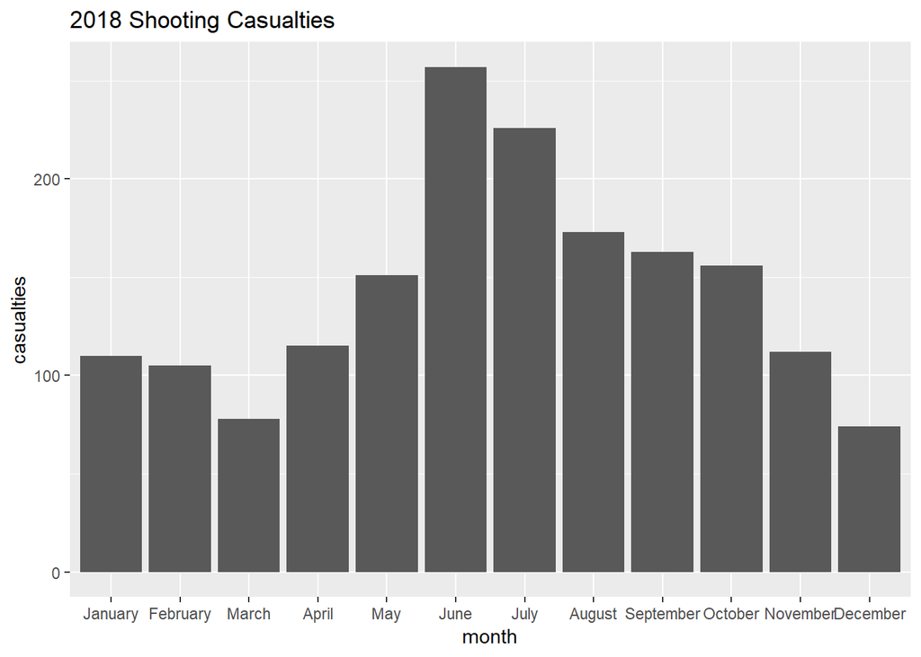

Looking at the graph, I first notice that the top 3 months with the highest casualties were summer months. Also, as the year went by after summer, the number of casualties slowly decreased overtime.

## Critical Reflection

I believe that this report can be used in many good ways. For example, legislators who write laws for gun control can use the map and maybe direct their energy toward states with the most shooting incidents (the Southeast for instance). However, if someone were to just focus on the map and work on areas with the most shootings, they most likely wouldn’t address the Chicago community which is the city with the highest number of casualties in the year. A big group of people could be neglected because of this.